# Weight Lifting Quality

## Summary

We identified major leakage in the weight lifting data. Afterwards we trained a model on the features not affected by the leakage. The model was a random forest, where we tuned the features used per tree. The model had a 5-fold CV accuracy of above 99% and we expect out of sample error to be similar. Indeed the model was able to correctly predict the 20 test cases.

## Data loading and libraries

```r
library(tidyverse)
library(lubridate)
library(caret)

training <- read.csv('pml-training.csv',
                     na.strings = c("NA",""),
                     stringsAsFactors = FALSE) %>% as_tibble()

testing <- read.csv('pml-testing.csv',
                    na.strings = c("NA",""),
                    stringsAsFactors = TRUE) %>%  as_tibble()
```

## EDA

### Leackage

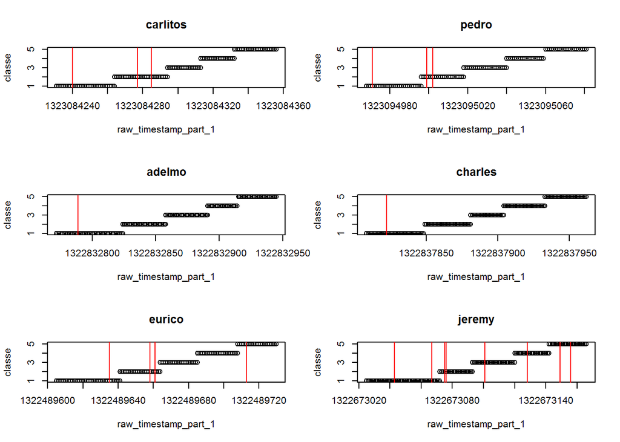

```r
scoreTimeDependence <- function(name) {
  training %>%
    filter(user_name == name) %>%
  {plot(x=.[['raw_timestamp_part_1']],y=factor(.[['classe']]),
    xlab='raw_timestamp_part_1',ylab='classe')}

  testing %>%
    filter(user_name == name) %>%
    {abline(v=.[['raw_timestamp_part_1']],col='red')}

  title(main = name)
}

unique_names <- training$user_name %>% unique()

par(mfrow=c(3,2))
for (n in unique_names) {
  scoreTimeDependence(n)
}
```

From this it can be seen that the the timestamp contains in fact leakage and can be used to make perfect prediction on the test set by matching the target according to the intercept. We assume that this is not in the spirit of the exercise and therefore exclude all features that possibly allow leakage of this type. This includes `raw_timestamp_part_1`, `raw_timestamp_part_2` `cvtd_timestamp`, `num_window` and `X`. The `num_window` feature is defined by timestamp and one can indeed check that each window number corresponds to exactly one target.

```r
training %>%
  group_by(num_window) %>%
  summarize(diff_cl = n_distinct(classe)) %>%
  arrange(desc(diff_cl)) %>%
  head()
```

```
## # A tibble: 6 x 2
##   num_window diff_cl
##        <int>   <int>
## 1          1       1
## 2          2       1
## 3          3       1
## 4          4       1
## 5          5       1
## 6          6       1
```

The sample number `X` contains leackage because the samples appear to be numbered chronologically, so `X` inherits the leackage from the timestamp feautres.

### New Window, aggregates and test data.

When looking at the percentage of missing values per column one notices that there is only one non-zero percentage for all columns with missing values.

```r
table(colMeans(is.na(training)))
```

```
##
##                 0 0.979308938946081
##                60               100
```

This suggests that the data might be missing conditional on some other variable and in fact, the `new_window` variable explains all the missing values. If new value equals *yes* there are no missing values.

```r
table(colMeans(is.na(training %>% filter(new_window == 'yes'))))
```

```
##
##   0
## 160
```

A more careful look at the missing columns shows that all missing values correspond to columns containing aggregated values like max, min, avg etc. Apparently the aggregates for a particular `num_window` are only written to the row with `new_window` equal to *yes*. How does this relate to the data which we want to predict? In fact all the testing data has `new_window` equal to *no* and as a consequence no aggregated values. The provided aggregated values can therefore not be used make reasonable predictions and are excluded in our model. As `new_window` contains no other useful information we also exclude it as a feature. Finally we derive a feature list for model training as follows.

```r
cs <- colSums(is.na(testing))
features <- names(cs[cs != 20])
exlist <- c('X','raw_timestamp_part_1','raw_timestamp_part_2','cvtd_timestamp',
            'new_window','num_window','problem_id')
features <- features[!features %in% exlist]
length(features)
```

```
## [1] 53
```

Where we additonally excluded the problem_id, as it is not part of the train set. As we can see we end up with 53 in the end.

Note that there is also a problem with “#DIV/0!” strings in the dataset. Since these only appear in aggregated columns we don’t have to deal with this issue since we excluded all these columns for our model.

```r
print("Training data has a '#DIV/0!' problem")
```

```
## [1] "Training data has a '#DIV/0!' problem"
```

```r
print(paste('Number occurences:',
            sum(apply(training,c(1,2),FUN = function(x) grepl('#DIV/0!',x)))))
```

```
## [1] "Number occurences: 3502"
```

```r
print("Our final features don't have the problem")
```

```
## [1] "Our final features don't have the problem"
```

```r
print(paste('Number occurences:',
            sum(apply(training[,features],c(1,2),FUN = function(x) grepl('#DIV/0!',x)))))
```

```
## [1] "Number occurences: 0"
```

## Model selection and model training

In order to select and tune a model we’ll rely on caret’s train function. We’ll configure the train control argument to perform 5-fold cross-validation using accuracy as a metric. Our goal is to train a random forest using the ‘rf’ method, because random forest are amount the strongest out of the box models. We’ll set the number of trees to 50 to keep the run time short and use a maximum number of nodes equal to 512 also to put a bound on run time. We’ll then let the model tune the mtry parameter, which controls how many features are used for each single tree in the forest. We supply a mtry grid with three values in order to demonstrate tuning while still keeping the overall report simple. We do not perform any explicit pre-processing on top of the feature selection (like centering or scaling) as it is not necessary for trees.

```r
  grid <- expand.grid(mtry=c(10,25,40))
  tc <- trainControl(method="cv",number = 5)
  mdl <- train(classe~.,
               data = training[,c(features,'classe')],
               metric = "Accuracy",
               method='rf',
               trControl = tc,
               maxnodes=512,
               ntree=50,
               tuneGrid = grid)
  print(mdl)
```

```
## Random Forest
##
## 19622 samples
##    53 predictor
##     5 classes: 'A', 'B', 'C', 'D', 'E'
##
## No pre-processing
## Resampling: Cross-Validated (5 fold)
## Summary of sample sizes: 15697, 15697, 15698, 15698, 15698
## Resampling results across tuning parameters:
##
##   mtry  Accuracy   Kappa
##   10    0.9873611  0.9840129
##   25    0.9922538  0.9902009
##   40    0.9920499  0.9899437
##
## Accuracy was used to select the optimal model using the largest value.
## The final value used for the model was mtry = 25.
```

Finally our predictions are

```r
predict(mdl,testing[,features])
```

```
##  [1] B A B A A E D B A A B C B A E E A B B B
## Levels: A B C D E
```

,which indeed all turned out to be correct. For an overall summary see the beginning of the report.